# Title

## Exploratory Analysis

### Check Interest rate vs FICO

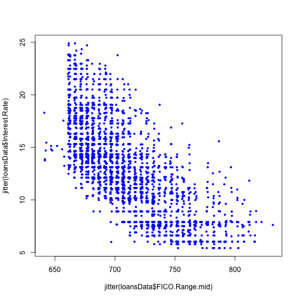

```r
plot(jitter(loansData$FICO.Range.mid), jitter(loansData$Interest.Rate), col = "blue",
    pch = 19, cex = 0.5)
```

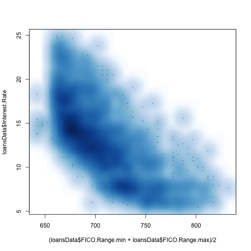

```r
smoothScatter((loansData$FICO.Range.min + loansData$FICO.Range.max)/2, loansData$Interest.Rate)
```

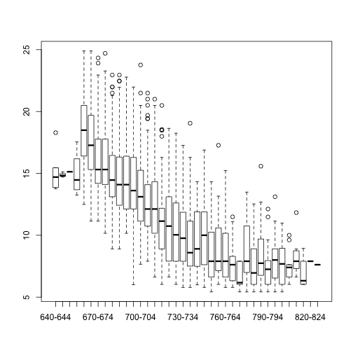

```r
# plot shows decrease in interest rates when FICO score increases
boxplot(Interest.Rate ~ FICO.Range, data = loansData)
```

### try alternate colorings based on Loan.purpose, home.ownership, etc.

see if anything significant about home ownership

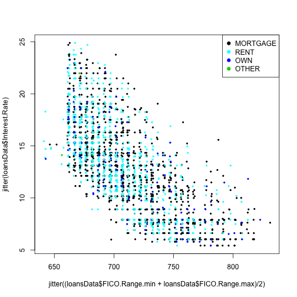

```r
plot(jitter((loansData$FICO.Range.min + loansData$FICO.Range.max)/2), jitter(loansData$Interest.Rate),
    col = as.numeric(loansData$Home.Ownership), pch = 19, cex = 0.4)
legend("topright", legend = unique(loansData$Home.Ownership), col = unique(as.numeric(loansData$Home.Ownership)),
    pch = 19)
```

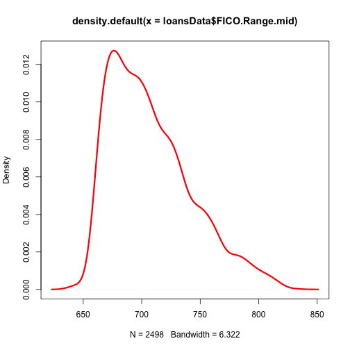

```r
plot(density(loansData$FICO.Range.mid), lwd = 3, col = "red")
```

#### Check FICO-related parameters

FICO scores are calculated using revolving credit balance, inquiries in the last 12 months (not 6), open credit lines

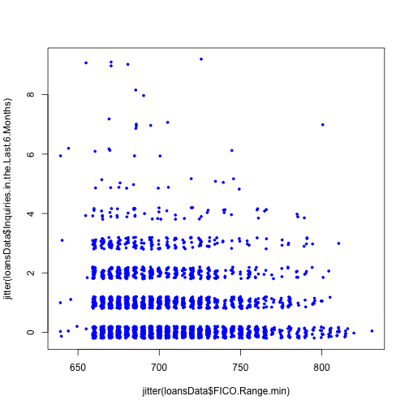

```r
plot(jitter(loansData$FICO.Range.min), jitter(loansData$Inquiries.in.the.Last.6.Months),
    col = "blue", pch = 19, cex = 0.5)
```

### Loan Length

As of this writing, Lending Club only allows 36-month terms for loans of $1000-$15,975, so naturally larger loan lengths will tend to be for higher amounts.

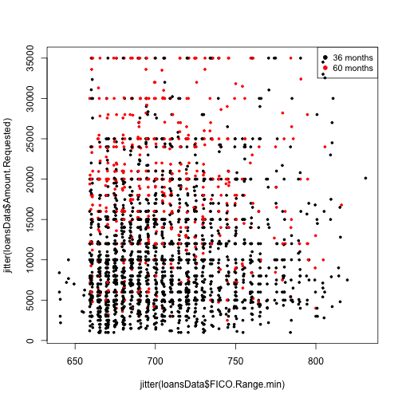

```r
plot(jitter(loansData$FICO.Range.min), jitter(loansData$Amount.Requested), col = as.numeric(loansData$Loan.Length),
    pch = 19, cex = 0.5)
legend("topright", legend = unique(loansData$Loan.Length), col = unique(as.numeric(loansData$Loan.Length)),
    pch = 19, cex = 0.9)
```

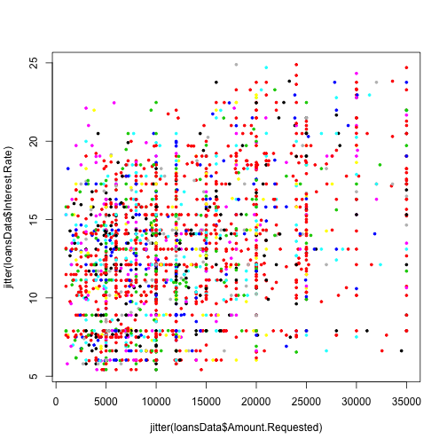

```r
plot(jitter(loansData$Amount.Requested), jitter(loansData$Interest.Rate), col = loansData$Employment.Length.num,
    pch = 19, cex = 0.5)
```

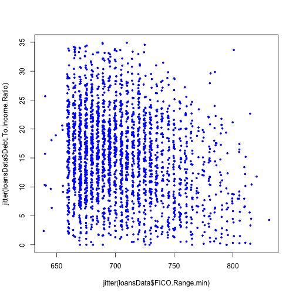

```r
plot(jitter(loansData$FICO.Range.min), jitter(loansData$Debt.To.Income.Ratio),
    col = "blue", pch = 19, cex = 0.5)
```

### Correlations

#### Check Interest Rates

```r
cor(loansData$Interest.Rate, loansData[, c(1, 2, 19, 22, 6, 21, 23, 9, 18, 11,
    12, 13, 20)])
```

```
##      Amount.Requested Amount.Funded.By.Investors Loan.Length.months
## [1,]           0.3318                     0.3368             0.4235
##      Loan.Purpose.num Debt.To.Income.Ratio State.num Home.Ownership.num
## [1,]         -0.06073               0.1722  0.008888            0.07503
##      Monthly.Income FICO.Range.mid Open.CREDIT.Lines
## [1,]        0.01292        -0.7092           0.09031
##      Revolving.CREDIT.Balance Inquiries.in.the.Last.6.Months
## [1,]                  0.06111                         0.1646
##      Employment.Length.num
## [1,]                    NA
```

Correlation indicates the following vars are highly correlated with Interest Rate: FICO.Range.mid(-0.7092), Loan.Length.months(0.4235), Amount.Funded.By.Investors(0.336), Amount.Requested(0.331), Debt.To.Income.Ratio(0.1722), Inquiries.in.the.Last.6.Months(0.1646)

### Check FICO score

```r
cor(loansData$FICO.Range.mid, loansData[, c(1, 2, 19, 22, 6, 21, 23, 9, 11,
    12, 13, 20)])
```

```
##      Amount.Requested Amount.Funded.By.Investors Loan.Length.months
## [1,]          0.08338                    0.07428             0.0127
##      Loan.Purpose.num Debt.To.Income.Ratio State.num Home.Ownership.num
## [1,]          0.09926               -0.217  0.001387            -0.1566
##      Monthly.Income Open.CREDIT.Lines Revolving.CREDIT.Balance
## [1,]         0.1227          -0.08944                 0.002917
##      Inquiries.in.the.Last.6.Months Employment.Length.num
## [1,]                       -0.09217                    NA
```

As expected, state does not correlate well (not in FICO score) Best vars are Debt.To.Income.Ratio(-0.2169), Home.Ownership.num (-0.156), Monthly.Income(0.122) Oddly, Inquiries in the last 6 months is low

## Modeling

### Start with basic linear regression model, using FICO score only

```r
palette(rainbow(14))
loansDataLm1 <- lm(Interest.Rate ~ FICO.Range.min, data = loansData)
summary(loansDataLm1)
```

```
##
## Call:
## lm(formula = Interest.Rate ~ FICO.Range.min, data = loansData)
##
## Residuals:
##    Min     1Q Median     3Q    Max
## -7.990 -2.136 -0.456  1.835 10.194
##
## Coefficients:
##                Estimate Std. Error t value Pr(>|t|)
## (Intercept)    72.83876    1.19066    61.2   <2e-16 ***
## FICO.Range.min -0.08467    0.00168   -50.3   <2e-16 ***
## ---
## Signif. codes:  0 '***' 0.001 '**' 0.01 '*' 0.05 '.' 0.1 ' ' 1
##
## Residual standard error: 2.95 on 2496 degrees of freedom
## Multiple R-squared: 0.503,   Adjusted R-squared: 0.503
## F-statistic: 2.53e+03 on 1 and 2496 DF,  p-value: <2e-16
```

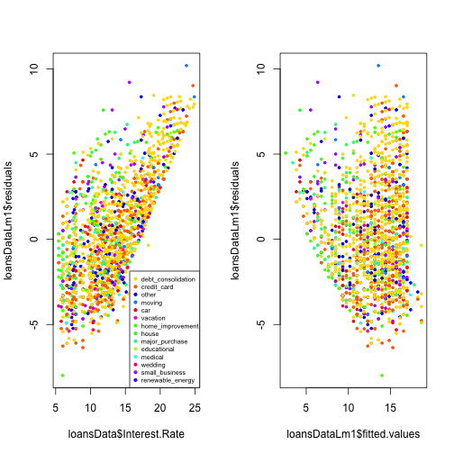

```r
par(mfrow = c(1, 2))
plot(loansData$Interest.Rate, loansDataLm1$residuals, col = as.numeric(loansData$Loan.Purpose),
    pch = 19, cex = 0.5)
legend("bottomright", legend = unique(loansData$Loan.Purpose), col = as.numeric(unique(loansData$Loan.Purpose)),
    pch = 19, cex = 0.6)
plot(loansDataLm1$fitted.values, loansDataLm1$residuals, col = as.numeric(loansData$Loan.Purpose),
    pch = 19, cex = 0.5)
```

### add in Loan Lengths

should probably make it into the factor version

```r
loansDataLm2 <- lm(Interest.Rate ~ FICO.Range.min + Amount.Requested + as.factor(Loan.Length),
    data = loansData)
summary(loansDataLm2)
```

```
##
## Call:
## lm(formula = Interest.Rate ~ FICO.Range.min + Amount.Requested +
##     as.factor(Loan.Length), data = loansData)
##
## Residuals:
##    Min     1Q Median     3Q    Max
## -9.761 -1.457 -0.132  1.262 10.295
##
## Coefficients:
##                                  Estimate Std. Error t value Pr(>|t|)
## (Intercept)                      7.26e+01   8.53e-01    85.1   <2e-16 ***
## FICO.Range.min                  -8.77e-02   1.21e-03   -72.4   <2e-16 ***
## Amount.Requested                 1.39e-04   5.96e-06    23.2   <2e-16 ***
## as.factor(Loan.Length)60 months  3.29e+00   1.12e-01    29.4   <2e-16 ***
## ---
## Signif. codes:  0 '***' 0.001 '**' 0.01 '*' 0.05 '.' 0.1 ' ' 1
##
## Residual standard error: 2.11 on 2494 degrees of freedom
## Multiple R-squared: 0.745,   Adjusted R-squared: 0.745
## F-statistic: 2.43e+03 on 3 and 2494 DF,  p-value: <2e-16
```

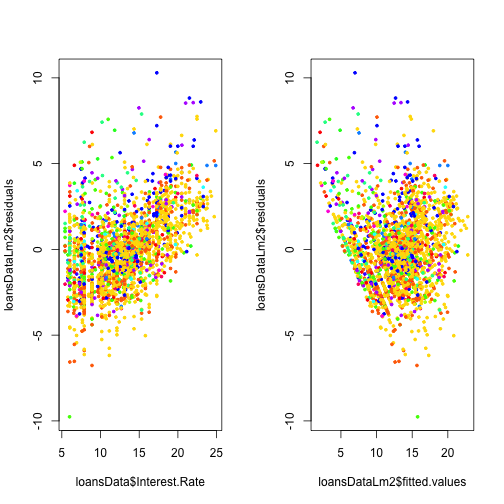

```r
par(mfrow = c(1, 2))
plot(loansData$Interest.Rate, loansDataLm2$residuals, col = as.numeric(loansData$Loan.Purpose),
    pch = 19, cex = 0.5)
plot(loansDataLm2$fitted.values, loansDataLm2$residuals, col = as.numeric(loansData$Loan.Purpose),
    pch = 19, cex = 0.5)
```

### add in Inquiries instead

Slightly better, R changed by 0.01

```r
loansDataLm3 <- lm(Interest.Rate ~ FICO.Range.min + Amount.Requested + as.factor(Loan.Length) +
    Inquiries.in.the.Last.6.Months, data = loansData)
summary(loansDataLm3)
```

```
##
## Call:
## lm(formula = Interest.Rate ~ FICO.Range.min + Amount.Requested +
##     as.factor(Loan.Length) + Inquiries.in.the.Last.6.Months,
##     data = loansData)
##
## Residuals:
##    Min     1Q Median     3Q    Max
## -9.405 -1.389 -0.162  1.231  9.888
##
## Coefficients:
##                                  Estimate Std. Error t value Pr(>|t|)
## (Intercept)                      7.15e+01   8.44e-01   84.72   <2e-16 ***
## FICO.Range.min                  -8.67e-02   1.19e-03  -72.63   <2e-16 ***
## Amount.Requested                 1.41e-04   5.86e-06   24.00   <2e-16 ***
## as.factor(Loan.Length)60 months  3.25e+00   1.10e-01   29.56   <2e-16 ***
## Inquiries.in.the.Last.6.Months   3.32e-01   3.38e-02    9.81   <2e-16 ***
## ---
## Signif. codes:  0 '***' 0.001 '**' 0.01 '*' 0.05 '.' 0.1 ' ' 1
##
## Residual standard error: 2.07 on 2493 degrees of freedom
## Multiple R-squared: 0.755,   Adjusted R-squared: 0.754
## F-statistic: 1.92e+03 on 4 and 2493 DF,  p-value: <2e-16
```

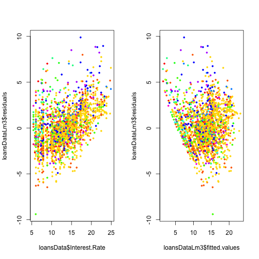

```r
par(mfrow = c(1, 2))
plot(loansData$Interest.Rate, loansDataLm3$residuals, col = as.numeric(loansData$Loan.Purpose),
    pch = 19, cex = 0.5)
plot(loansDataLm3$fitted.values, loansDataLm3$residuals, col = as.numeric(loansData$Loan.Purpose),
    pch = 19, cex = 0.5)
```

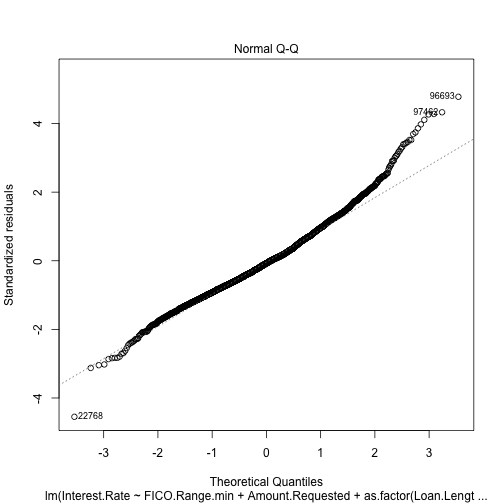

```r
par(mfrow = c(1, 1))
plot(loansDataLm3, which = 2)
```

```r
confint(loansDataLm3)
```

```
##                                      2.5 %    97.5 %
## (Intercept)                     69.8540691 73.164334
## FICO.Range.min                  -0.0890403 -0.084359
## Amount.Requested                 0.0001291  0.000152
## as.factor(Loan.Length)60 months  3.0365787  3.468072
## Inquiries.in.the.Last.6.Months   0.2655349  0.398269
```

### Check confounding

```r
confoundlm <- lm(Amount.Requested ~ as.factor(Loan.Length), data = loansData)
summary(confoundlm)
```

```
##
## Call:
## lm(formula = Amount.Requested ~ as.factor(Loan.Length), data = loansData)
##
## Residuals:
##    Min     1Q Median     3Q    Max
## -15979  -5208   -708   4292  24292
##
## Coefficients:
##                                 Estimate Std. Error t value Pr(>|t|)
## (Intercept)                        10708        161    66.5   <2e-16 ***
## as.factor(Loan.Length)60 months     7771        344    22.6   <2e-16 ***
## ---
## Signif. codes:  0 '***' 0.001 '**' 0.01 '*' 0.05 '.' 0.1 ' ' 1
##
## Residual standard error: 7110 on 2496 degrees of freedom
## Multiple R-squared: 0.17,    Adjusted R-squared: 0.17
## F-statistic:  511 on 1 and 2496 DF,  p-value: <2e-16
```

### Retry using FICO range as factor

with confounder, adjusted R-squared: of 0.796

```r
loansDataLm4 <- lm(Interest.Rate ~ as.factor(FICO.Range) + Amount.Requested +
    as.factor(Loan.Length) + Inquiries.in.the.Last.6.Months, data = loansData)
summary(loansDataLm4)
```

```
##
## Call:
## lm(formula = Interest.Rate ~ as.factor(FICO.Range) + Amount.Requested +
##     as.factor(Loan.Length) + Inquiries.in.the.Last.6.Months,
##     data = loansData)
##
## Residuals:
##    Min     1Q Median     3Q    Max
## -9.290 -1.183 -0.109  1.044 10.087
##
## Coefficients:
##                                  Estimate Std. Error t value Pr(>|t|)
## (Intercept)                      1.38e+01   8.49e-01   16.29  < 2e-16 ***
## as.factor(FICO.Range)645-649    -9.25e-01   1.38e+00   -0.67  0.50369
## as.factor(FICO.Range)650-654     2.73e-01   2.07e+00    0.13  0.89533
## as.factor(FICO.Range)655-659    -8.25e-01   1.27e+00   -0.65  0.51632
## as.factor(FICO.Range)660-664     1.72e+00   8.65e-01    1.99  0.04695 *
## as.factor(FICO.Range)665-669     1.11e+00   8.62e-01    1.29  0.19795
## as.factor(FICO.Range)670-674     4.01e-02   8.60e-01    0.05  0.96280
## as.factor(FICO.Range)675-679    -6.28e-01   8.61e-01   -0.73  0.46561
## as.factor(FICO.Range)680-684    -1.40e+00   8.61e-01   -1.63  0.10402
## as.factor(FICO.Range)685-689    -1.98e+00   8.63e-01   -2.30  0.02152 *
## as.factor(FICO.Range)690-694    -2.13e+00   8.64e-01   -2.47  0.01374 *
## as.factor(FICO.Range)695-699    -2.71e+00   8.62e-01   -3.14  0.00169 **
## as.factor(FICO.Range)700-704    -3.44e+00   8.64e-01   -3.98  7.2e-05 ***
## as.factor(FICO.Range)705-709    -4.16e+00   8.64e-01   -4.82  1.5e-06 ***
## as.factor(FICO.Range)710-714    -4.34e+00   8.67e-01   -5.00  6.0e-07 ***
## as.factor(FICO.Range)715-719    -5.37e+00   8.71e-01   -6.17  8.0e-10 ***
## as.factor(FICO.Range)720-724    -5.64e+00   8.67e-01   -6.51  9.1e-11 ***
## as.factor(FICO.Range)725-729    -6.03e+00   8.70e-01   -6.93  5.4e-12 ***
## as.factor(FICO.Range)730-734    -6.80e+00   8.71e-01   -7.81  8.3e-15 ***
## as.factor(FICO.Range)735-739    -7.32e+00   8.81e-01   -8.31  < 2e-16 ***
## as.factor(FICO.Range)740-744    -7.31e+00   8.88e-01   -8.24  2.9e-16 ***
## as.factor(FICO.Range)745-749    -7.31e+00   8.87e-01   -8.24  2.7e-16 ***
## as.factor(FICO.Range)750-754    -7.80e+00   8.82e-01   -8.84  < 2e-16 ***
## as.factor(FICO.Range)755-759    -8.00e+00   8.93e-01   -8.96  < 2e-16 ***
## as.factor(FICO.Range)760-764    -7.82e+00   8.93e-01   -8.76  < 2e-16 ***
## as.factor(FICO.Range)765-769    -8.41e+00   9.05e-01   -9.29  < 2e-16 ***
## as.factor(FICO.Range)770-774    -9.29e+00   9.65e-01   -9.63  < 2e-16 ***
## as.factor(FICO.Range)775-779    -8.26e+00   9.40e-01   -8.79  < 2e-16 ***
## as.factor(FICO.Range)780-784    -8.99e+00   9.20e-01   -9.77  < 2e-16 ***
## as.factor(FICO.Range)785-789    -8.57e+00   9.53e-01   -8.99  < 2e-16 ***
## as.factor(FICO.Range)790-794    -9.07e+00   9.48e-01   -9.57  < 2e-16 ***
## as.factor(FICO.Range)795-799    -9.00e+00   9.98e-01   -9.02  < 2e-16 ***
## as.factor(FICO.Range)800-804    -8.79e+00   1.01e+00   -8.71  < 2e-16 ***
## as.factor(FICO.Range)805-809    -9.44e+00   1.02e+00   -9.22  < 2e-16 ***
## as.factor(FICO.Range)810-814    -8.38e+00   1.08e+00   -7.74  1.5e-14 ***
## as.factor(FICO.Range)815-819    -9.10e+00   1.15e+00   -7.92  3.5e-15 ***
## as.factor(FICO.Range)820-824    -7.03e+00   2.07e+00   -3.39  0.00071 ***
## as.factor(FICO.Range)830-834    -9.14e+00   2.08e+00   -4.40  1.1e-05 ***
## Amount.Requested                 1.45e-04   5.41e-06   26.86  < 2e-16 ***
## as.factor(Loan.Length)60 months  3.23e+00   1.01e-01   31.91  < 2e-16 ***
## Inquiries.in.the.Last.6.Months   3.27e-01   3.14e-02   10.44  < 2e-16 ***
## ---
## Signif. codes:  0 '***' 0.001 '**' 0.01 '*' 0.05 '.' 0.1 ' ' 1
##
## Residual standard error: 1.89 on 2457 degrees of freedom
## Multiple R-squared: 0.798,   Adjusted R-squared: 0.795
## F-statistic:  243 on 40 and 2457 DF,  p-value: <2e-16
```

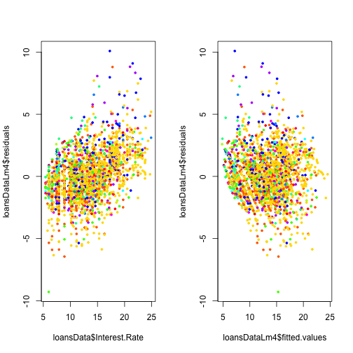

```r
par(mfrow = c(1, 2))
plot(loansData$Interest.Rate, loansDataLm4$residuals, col = as.numeric(loansData$Loan.Purpose),
    pch = 19, cex = 0.5)
plot(loansDataLm4$fitted.values, loansDataLm4$residuals, col = as.numeric(loansData$Loan.Purpose),
    pch = 19, cex = 0.5)
```

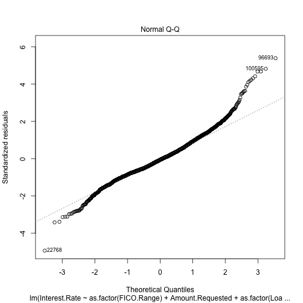

```r
# P value is >0.001 but <0.01, so not sure if OK
par(mfrow = c(1, 1))
plot(loansDataLm4, which = 2)
```